# Tugas P2 MPDW

Farhan Abdillah Harahap

2023-09-09

##Library

```r
library(dplyr)
library(TTR)
library(lmtest) # uji-Durbin Watson
library(orcutt) # Cochrane-Orcutt
library(HoRM) # Hildreth Lu
```

```r
library(corrplot)
library(knitr)
library(ggplot2)
library(rio)
library(olsrr)
library(GGally)
```

##Penjelasan Data Data “Wind Power Forecasting” dapat diakses melalui https://www.kaggle.com/datasets/theforcecoder/wind-power-forecasting. Data ini berisi berbagai fitur cuaca, turbin dan rotor. Data dicatat dari Januari 2018 hingga Maret 2020. Pembacaan dicatat dengan interval 10 menit. Berikut adalah informasi data yang digunakan pada penelitian ini:

```r
data <- data.frame(
  Kode = c("Y", "X1", "X2", "X3", "X4", "X5", "X6"),
  Variabel = c("ActivePower", "AmbientTemperature", "BearingShaftTemperature",
                "GearboxBearingTemperature", "GeneratorRPM", "MainBoxTemperature",
                "ReactivePower")
)

data
```

```
##   Kode                  Variabel
## 1    Y               ActivePower
## 2   X1        AmbientTemperature
## 3   X2   BearingShaftTemperature
## 4   X3 GearboxBearingTemperature
## 5   X4              GeneratorRPM
## 6   X5        MainBoxTemperature
## 7   X6             ReactivePower
```

##Eksplorasi Data ###Import Data

```r
data<- import("https://raw.githubusercontent.com/farhanabdillahh/PraktikumMPDW/main/Pertemuan%202/datasetmpdwpert2.csv")
data <- data %>% slice(1:100) #Fokus mengambil 100 periode teratas
str(data)
```

```
## 'data.frame':    100 obs. of  8 variables:
##  $ Date: POSIXct, format: "2018-08-17 16:20:00" "2018-08-17 16:30:00" ...
##  $ Y   : num  1719 1721 1721 1737 1721 ...
##  $ X1  : num  27.7 27.6 27.5 27.3 27.2 ...
##  $ X2  : num  48 48 48.1 48.3 48.3 ...
##  $ X3  : num  76.8 76.7 76.6 76.4 76.3 ...
##  $ X4  : num  1756 1753 1751 1749 1761 ...
##  $ X5  : num  40.9 40.8 40.7 40.6 40.6 ...
##  $ X6  : num  0.715 -0.272 1.128 0.724 -0.164 ...
```

###Plot Korelasi

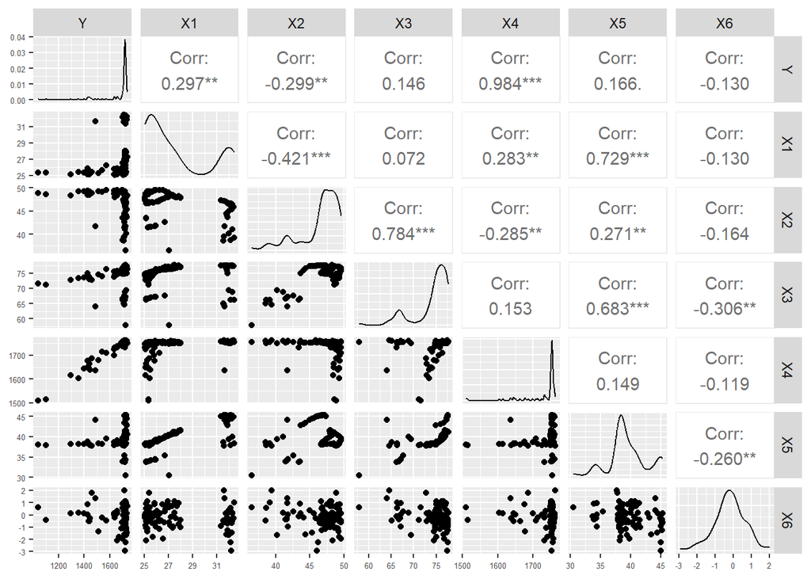

```r
# Menghasilkan plot ggpairs
plot <- ggpairs(data[sapply(data, is.numeric)])

# Mengatur ukuran font pada semua elemen
plot <- plot + theme(
  axis.text = element_text(size = 5),
  axis.title = element_text(size = 5),
  legend.text = element_text(size = 5)
)

# Tampilkan gambar
print(plot)
```

Terdapat Korelasi yang tinggi antara Peubah Y (Active Power) dan X4 (GeneratorPRM)

##Regresi Global ###Model Regresi OLS

```r
#Pembuatan Model Regresi
model<- lm(Y ~ X1 + X2 + X3 + X4 + X5 + X6 , data = data)
summary(model)
```

```
##
## Call:
## lm(formula = Y ~ X1 + X2 + X3 + X4 + X5 + X6, data = data)
##
## Residuals:
##     Min      1Q  Median      3Q     Max
## -68.967  -7.346  -0.258   9.375  77.785
##
## Coefficients:
##               Estimate Std. Error t value Pr(>|t|)
## (Intercept) -2605.2007   162.7698 -16.005  < 2e-16 ***
## X1            -11.9964     3.7241  -3.221  0.00176 **
## X2             -7.4402     3.0037  -2.477  0.01506 *
## X3             -1.4997     2.2385  -0.670  0.50455
## X4              2.6468     0.0752  35.199  < 2e-16 ***
## X5             11.7440     3.6109   3.252  0.00160 **
## X6             -2.6518     2.7925  -0.950  0.34477
## ---
## Signif. codes:  0 '***' 0.001 '**' 0.01 '*' 0.05 '.' 0.1 ' ' 1
##
## Residual standard error: 22.2 on 93 degrees of freedom
## Multiple R-squared:  0.9721, Adjusted R-squared:  0.9703
## F-statistic: 539.5 on 6 and 93 DF,  p-value: < 2.2e-16
```

Model regresi global menjelaskan bahwa terdapat 4 peubah yang berpengaruh signifikan terhadap peubah respon, yaitu Ambient Temperature (X1), Bearing Shaft Temperature (X2), GeneratorPRM (X4), dan Main Box Temperature (X5) dengan Koefisien Determinasi sebesar 97.21%.

###Model Regresi Terbaik

```r
bestsubset <- ols_step_best_subset(model)
bestsubset
```

```
##     Best Subsets Regression
## --------------------------------
## Model Index    Predictors
## --------------------------------
##      1         X4
##      2         X2 X4
##      3         X2 X4 X5
##      4         X1 X2 X4 X5
##      5         X1 X2 X4 X5 X6
##      6         X1 X2 X3 X4 X5 X6
## --------------------------------
##
##                                                       Subsets Regression Summary
## --------------------------------------------------------------------------------------------------------------------------------------
##                        Adj.        Pred
## Model    R-Square    R-Square    R-Square     C(p)        AIC         SBIC        SBC          MSEP         FPE        HSP       APC
## --------------------------------------------------------------------------------------------------------------------------------------
##   1        0.9676      0.9673      0.9651    11.8046    917.3319    633.2441    925.1474    54220.7450    553.0493    5.5897    0.0337
##   2        0.9680      0.9674      0.9644    12.5064    918.1204    633.9587    928.5411    54125.8492    557.4347    5.6375    0.0340
##   3        0.9688      0.9678      0.9643    11.9258    917.6676    633.5748    930.6934    53370.3166    554.9298    5.6167    0.0338
##   4        0.9717      0.9705      0.9665     4.1849    909.8259    626.6480    925.4570    48882.5391    513.0974    5.1986    0.0313
##   5        0.9719      0.9704      0.9656     5.4488    911.0413    628.0850    929.2775    49022.0039    519.4031    5.2688    0.0316
##   6        0.9721      0.9703      0.9534     7.0000    912.5599    629.8146    933.4012    49316.8391    527.3955    5.3575    0.0321
## --------------------------------------------------------------------------------------------------------------------------------------
## AIC: Akaike Information Criteria
##  SBIC: Sawa's Bayesian Information Criteria
##  SBC: Schwarz Bayesian Criteria
##  MSEP: Estimated error of prediction, assuming multivariate normality
##  FPE: Final Prediction Error
##  HSP: Hocking's Sp
##  APC: Amemiya Prediction Criteria
```

Model terbaik dengan kriteria AIC terkecil adalah model dengan peubah bebas X1, X2, X4, dan X5

```r
modelbest<- lm(Y ~ X1 + X2 + X4 + X5 , data = data)
summary(modelbest)
```

```
##
## Call:
## lm(formula = Y ~ X1 + X2 + X4 + X5, data = data)
##
## Residuals:
##     Min      1Q  Median      3Q     Max
## -71.837  -7.399  -1.050   8.366  76.631
##
## Coefficients:
##               Estimate Std. Error t value Pr(>|t|)
## (Intercept) -2.585e+03  1.471e+02 -17.578  < 2e-16 ***
## X1          -1.133e+01  3.615e+00  -3.135 0.002290 **
## X2          -8.447e+00  2.413e+00  -3.500 0.000710 ***
## X4           2.617e+00  5.172e-02  50.595  < 2e-16 ***
## X5           1.050e+01  3.048e+00   3.445 0.000853 ***
## ---
## Signif. codes:  0 '***' 0.001 '**' 0.01 '*' 0.05 '.' 0.1 ' ' 1
##
## Residual standard error: 22.11 on 95 degrees of freedom
## Multiple R-squared:  0.9717, Adjusted R-squared:  0.9705
## F-statistic: 815.9 on 4 and 95 DF,  p-value: < 2.2e-16
```

Selanjutnya dilakukan pemeriksaan multikolinieritas, multikolinieritas terjadi ketika VIF > 10. Pada kasus ini, peubah X1 dikeluarkan dari model karen VIF > 10. Oleh karena itu, model terbaik adalah dengan peubah bebas X2, X4, dan X5.

```r
car::vif(modelbest)
```

```
##       X1       X2       X4       X5
## 18.94969 10.13287  1.20575 17.28277
```

```r
modelbest <- lm(Y ~ X2 + X4 + X5 , data = data)
car::vif(modelbest)
```

```
##       X2       X4       X5
## 1.222459 1.158229 1.148949
```

```r
summary(modelbest)
```

```
##
## Call:
## lm(formula = Y ~ X2 + X4 + X5, data = data)
##
## Residuals:
##     Min      1Q  Median      3Q     Max
## -78.579  -6.781   1.336   9.046  71.502
##
## Coefficients:
##               Estimate Std. Error t value Pr(>|t|)
## (Intercept) -2.917e+03  1.067e+02 -27.345   <2e-16 ***
## X2          -1.353e+00  8.760e-01  -1.545    0.126
## X4           2.649e+00  5.296e-02  50.009   <2e-16 ***
## X5           1.268e+00  8.212e-01   1.544    0.126
## ---
## Signif. codes:  0 '***' 0.001 '**' 0.01 '*' 0.05 '.' 0.1 ' ' 1
##
## Residual standard error: 23.1 on 96 degrees of freedom
## Multiple R-squared:  0.9688, Adjusted R-squared:  0.9678
## F-statistic: 993.3 on 3 and 96 DF,  p-value: < 2.2e-16
```

##Pemeriksaan Asumsi Autokorelasi ###Uji Eksploratif

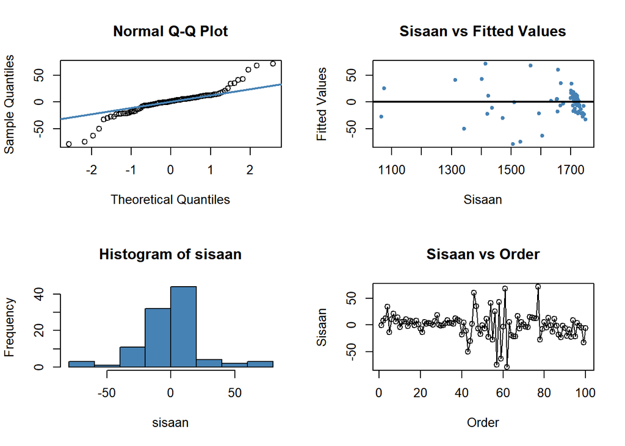

```r
#sisaan dan fitted value
sisaan<- residuals(modelbest)
fitValue<- predict(modelbest)

#Diagnostik dengan eksploratif
par(mfrow = c(2,2))
qqnorm(sisaan)
qqline(sisaan, col = "steelblue", lwd = 2)
plot(fitValue, sisaan, col = "steelblue", pch = 20, xlab = "Sisaan", ylab = "Fitted Values", main = "Sisaan vs Fitted Values")
abline(a = 0, b = 0, lwd = 2)
hist(sisaan, col = "steelblue")
plot(sisaan, type="o",
     ylab = "Sisaan", xlab = "Order", main = "Sisaan vs Order")
```

Selanjutnya mari fokuskan pada asumsi autokorelasi

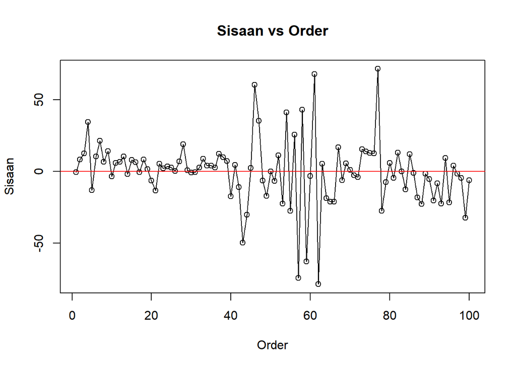

```r
residual <- residuals(modelbest)

plot(residual, type="o",
     ylab = "Sisaan", xlab = "Order", main = "Sisaan vs Order")
abline(h = 0, col='red')
```

Secara eksploratif, plot Sisaan vs Order memperlihatkan pola naik turun yang mengindikasikan keberadaan autokorelasi.

###Uji ACF dan PACF

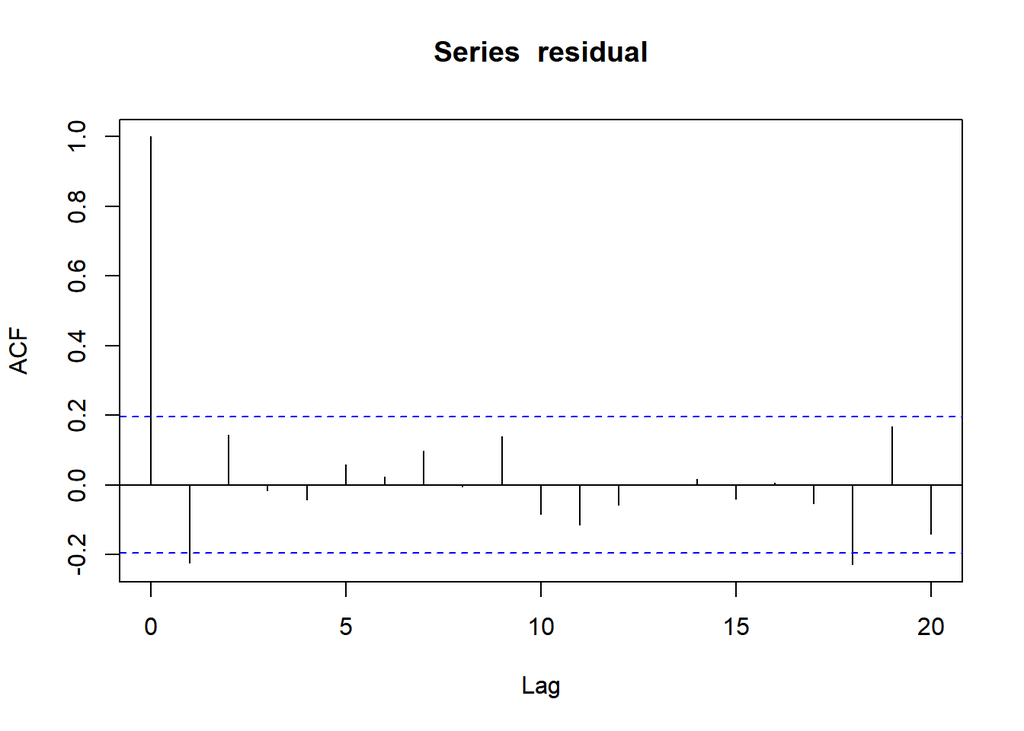

```r
acf(residual)
```

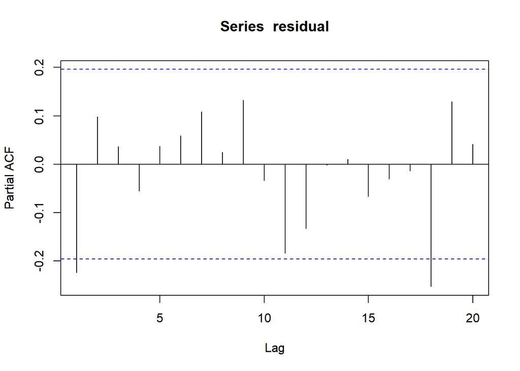

```r
pacf(residual)
```

###Uji Formal: Durbin Watson H0: Tidak ada autokorelasi H1: Ada autokorelasi

```r
lmtest::dwtest(modelbest, alternative = 'two.sided')
```

```
##
##  Durbin-Watson test
##
## data:  modelbest
## DW = 2.4466, p-value = 0.03703
## alternative hypothesis: true autocorrelation is not 0
```

p-value < 0.05. Maka, Tolak H0. Berarti, terdapat autokorelasi dalam model.

##Penanganan Autokorelasi ###Metode Cochrane-Orcutt

```r
#Penanganan Autokorelasi Cochrane-Orcutt
modelCO<-cochrane.orcutt(modelbest)
modelCO
```

```
## Cochrane-orcutt estimation for first order autocorrelation
##
## Call:
## lm(formula = Y ~ X2 + X4 + X5, data = data)
##
##  number of interaction: 8
##  rho -0.25787
##
## Durbin-Watson statistic
## (original):    2.44657 , p-value: 9.815e-01
## (transformed): 1.95758 , p-value: 1.378e-01
##
##  coefficients:
##  (Intercept)           X2           X4           X5
## -2980.745062    -1.184565     2.689922     0.866220
```

Selanjutnya akan dilakukan transformasi secara manual dengan syntax berikut ini.

```r
#Rho optimum
rho<- modelCO$rho
rho
```

```
## [1] -0.2578695
```

```r
#Transformasi Manual
Y.trans<- data$Y[-1]-data$Y[-100]*rho
X2.trans<- data$X2[-1]-data$X2[-100]*rho
X4.trans<- data$X4[-1]-data$X4[-100]*rho
X5.trans<- data$X5[-1]-data$X5[-100]*rho

modelCOmanual<- lm(Y.trans ~ X2.trans + X4.trans + X5.trans)
summary(modelCOmanual)
```

```
##
## Call:
## lm(formula = Y.trans ~ X2.trans + X4.trans + X5.trans)
##
## Residuals:
##     Min      1Q  Median      3Q     Max
## -64.750  -8.011   0.049   7.918  81.448
##
## Coefficients:
##               Estimate Std. Error t value Pr(>|t|)
## (Intercept) -3.749e+03  1.156e+02 -32.433   <2e-16 ***
## X2.trans    -1.185e+00  7.565e-01  -1.566    0.121
## X4.trans     2.690e+00  4.391e-02  61.257   <2e-16 ***
## X5.trans     8.662e-01  6.739e-01   1.285    0.202
## ---
## Signif. codes:  0 '***' 0.001 '**' 0.01 '*' 0.05 '.' 0.1 ' ' 1
##
## Residual standard error: 22.52 on 95 degrees of freedom
## Multiple R-squared:  0.9799, Adjusted R-squared:  0.9793
## F-statistic:  1544 on 3 and 95 DF,  p-value: < 2.2e-16
```

Hasil model transformasi bukan merupakan model sesungguhnya. Koefisien regresi masih perlu dicari kembali.

```r
#Mencari Penduga Koefisien Regresi setelah Transformasi ke Persamaan Awal
b0bintang <- modelCOmanual$coefficients[-(2:5)]
b0 <- b0bintang/(1-rho)
b1 <- modelCOmanual$coefficients[-1]
b0
```

```
## (Intercept)
##   -2980.745
```

```r
b1
```

```
##   X2.trans   X4.trans   X5.trans
## -1.1845645  2.6899218  0.8662205
```

Hasil perhitungan koefisien regresi tersebut akan menghasilkan hasil yang sama dengan model yang dihasilkan menggunakan *packages*. Selanjutnya dilakukan pemeriksaan autokorelasi kembali.

```r
lmtest::dwtest(modelCO, alternative = 'two.sided')
```

```
##
##  Durbin-Watson test
##
## data:  modelCO
## DW = 1.9576, p-value = 0.2756
## alternative hypothesis: true autocorrelation is not 0
```

p-value > 0.05. Artinya Tak Tolak H0. Maka, belum cukup bukti menyatakan bahwa ada autokorelasi dalam model. Oleh karena itu, masalah autokorelasi terselesaikan menggunakan metode ini

###Metode Hildreth-Lu Penanganan kedua adalah menggunakan metode Hildreth-Lu. Metode ini akan mencari nilai SSE terkecil dan dapat dicari secara manual maupun menggunakan packages. Jika menggunakan packages, gunakan `library` *packages* `HORM`. Berikut adalah function Hildreth Lu untuk 4 variabel yang digunakan.

```r
#Penanganan Autokorelasi Hildreth lu
# Hildreth-Lu
hildreth.lu.func<- function(r, modelbest){
  x2 <- model.matrix(modelbest)[,2]
  x4 <- model.matrix(modelbest)[,3]
  x5 <- model.matrix(modelbest)[,4]

  y <- model.response(model.frame(modelbest))
  n <- length(y)
  t <- 2:n
  y <- y[t]-r*y[t-1]
  x2 <- x2[t]-r*x2[t-1]
  x4 <- x4[t]-r*x4[t-1]
  x5 <- x5[t]-r*x5[t-1]

  return(lm(y~x2+x4+x5))
}

#Pencariab rho yang meminimumkan SSE
r <- c(seq(-0.9,0.9, by= 0.1))
tab <- data.frame("rho" = r, "SSE" = sapply(r, function(i){deviance(hildreth.lu.func(i, modelbest))}))
round(tab, 4)
```

```
##     rho      SSE
## 1  -0.9 68971.26
## 2  -0.8 62935.18
## 3  -0.7 57942.24
## 4  -0.6 53988.56
## 5  -0.5 51067.05
## 6  -0.4 49165.88
## 7  -0.3 48266.33
## 8  -0.2 48339.93
## 9  -0.1 49345.13
## 10  0.0 51223.92
## 11  0.1 53900.13
## 12  0.2 57282.56
## 13  0.3 61277.75
## 14  0.4 65816.41
## 15  0.5 70890.45
## 16  0.6 76583.10
## 17  0.7 83063.77
## 18  0.8 90533.78
## 19  0.9 99171.75
```

Berdasarkan iterasi rho dari rentang -0.9 sampai 0.9 dengan looping sebesar 0.1 didapatkan rho teroptimum adalah rho = -0.3 dengan SSE terkecil. Supaya rho yang didapatkan lebih teliti selanjutnya dilakukan iterasi kembali dari -0.4 sampai -0.2 dengan looping sebesar 0.001

```r
#Rho optimal di sekitar 0.3
rOpt <- seq(-0.4,-0.2, by= 0.001)
tabOpt <- data.frame("rho" = rOpt, "SSE" = sapply(rOpt, function(i){deviance(hildreth.lu.func(i, modelbest))}))
head(tabOpt[order(tabOpt$SSE),])
```

```
##        rho      SSE
## 143 -0.258 48180.77
## 144 -0.257 48180.81
## 142 -0.259 48180.83
## 145 -0.256 48180.94
## 141 -0.260 48180.99
## 146 -0.255 48181.17
```

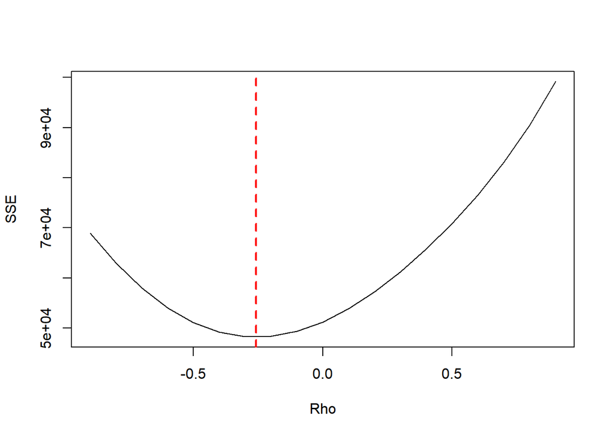

```r
#Grafik SSE optimum
par(mfrow = c(1,1))
plot(tab$SSE ~ tab$rho , type = "l", xlab = "Rho", ylab = "SSE")
abline(v = tabOpt[tabOpt$SSE==min(tabOpt$SSE),"rho"], lty = 2, col="red",lwd=2)
```

rho teroptimum adalah -0.258. Selanjutnya dilakukan pemodelan dengan rho = -0.258.

```r
#Model terbaik
modelHL <- hildreth.lu.func(-0.258, modelbest)
summary(modelHL)
```

```
##
## Call:
## lm(formula = y ~ x2 + x4 + x5)
##
## Residuals:
##     Min      1Q  Median      3Q     Max
## -64.745  -8.006   0.047   7.918  81.452
##
## Coefficients:
##               Estimate Std. Error t value Pr(>|t|)
## (Intercept) -3.750e+03  1.156e+02 -32.435   <2e-16 ***
## x2          -1.185e+00  7.564e-01  -1.566    0.121
## x4           2.690e+00  4.391e-02  61.262   <2e-16 ***
## x5           8.661e-01  6.739e-01   1.285    0.202
## ---
## Signif. codes:  0 '***' 0.001 '**' 0.01 '*' 0.05 '.' 0.1 ' ' 1
##
## Residual standard error: 22.52 on 95 degrees of freedom
## Multiple R-squared:  0.9799, Adjusted R-squared:  0.9793
## F-statistic:  1544 on 3 and 95 DF,  p-value: < 2.2e-16
```

```r
#Deteksi autokorelasi
dwtest(modelHL, , alternative = 'two.sided')
```

```
##
##  Durbin-Watson test
##
## data:  modelHL
## DW = 1.9573, p-value = 0.2772
## alternative hypothesis: true autocorrelation is not 0
```

Berdasarkan uji DW, didapatkan bahwa asumsi autokorelasi dapat teratasi

```r
#Perbandingan
sseModelawal <- anova(modelbest)$`Sum Sq`[-(1:3)]
sseModelCO <- anova(modelCOmanual)$`Sum Sq`[-(1:3)]
sseModelHL <- anova(modelHL)$`Sum Sq`[-(1:3)]
mseModelawal <- sseModelawal/length(data$Y)
mseModelCO <- sseModelCO/length(data$Y)
mseModelHL <- sseModelHL/length(data$Y)
akurasi <- matrix(c(sseModelawal,sseModelCO,sseModelHL,
                    mseModelawal,mseModelCO,mseModelHL),nrow=2,ncol=3,byrow = T)
colnames(akurasi) <- c("Model Awal", "Model Cochrane-Orcutt", "Model Hildreth-Lu")
row.names(akurasi) <- c("SSE","MSE")
akurasi
```

```
##     Model Awal Model Cochrane-Orcutt Model Hildreth-Lu
## SSE 51224.2885            48180.7714        48180.7722
## MSE   512.2429              481.8077          481.8077
```

```r
kable(akurasi)
```

|  | Model Awal | Model Cochrane-Orcutt | Model Hildreth-Lu |
| --- | --- | --- | --- |
| SSE | 51224.2885 | 48180.7714 | 48180.7722 |
| MSE | 512.2429 | 481.8077 | 481.8077 |

Berdasarkan hasil diatas, metode Cochrane-Orcutt dan metode Hildreth-Lu dapat mengatasi masalah autokorelasi serta memiliki nilai SSE dan MSE yang lebih kecil dibanding model OLS.

##Kesimpulan dan Saran

Autokorelasi yang terdapat pada data Wind Power Forecasting terjadi akibat adanya korelasi di antara unsur penyusunnya. Indikator Wind Power Forecasting yang erat hubungannya dengan perekonomian sangat rawan menjadi penyebab adanya autokorelasi. Adanya autokorelasi menyebabkan model regresi kurang baik karena akan meingkatkan galatnya. Autokorelasi dapat dideteksi secara eksploratif melalui plot sisaan, ACF, dan PACF, serta dengan uji formal Durbin-Watson. Namun, autokorelasi tersebut dapat ditangani dengan metode Cochrane-Orcutt dan Hildreth-Lu. Kedua metode menghasilkan nilai SSE yang sama, artinya keduanya baik untuk digunakan.